# 一人当たりGDPでみる日本 〜 今と昔と大昔 〜

## はじめに：経済学とは

- 経済学は大きく２つに分けることができる。
- ミクロ経済学
  - 個人、企業、産業に関する研究
  - 「昼食に蕎麦ではなくうどんを選ぶメカニズム」
  - 企業間の戦略的な行動
- マクロ経済学
  - 経済全体に関する研究分野
  - GDPの決定、インフレーション、失業、日本銀行の政策
- マクロ経済学における最も重要な問い
  1. ある国は貧しく、他の国は豊かな理由はなにか
  2. 景気循環はなぜ発生するのか
- 両方の問いでは、まずはGDPもしくは一人当たりGDPを使い考察することになる

## GDPの重要性

- 国内総生産
  - **G**ross **D**omestic **P**roduct → **GDP**
  - 経済全体で生産された財・サービス(最終財)を円単位で合計  
    → 総生産と呼ぶ
- なぜ重要?
  - 景気循環 ← GDPの変動
  - 失業 ← GDPと反対方向に動く
  - インフレ ← GDP と同じ方向に動く
  - 利子率 ← GDP と同じ方向に動く
  - **生活する上で無視できない**
- GDPはどのように決定されるのか？

## GDP：もっと詳しく

経済を財・サービスとお金の流れで考えよう

- GDP = 総生産
  - 経済全体で生産された財・サービス（最終財）を円単位で合計
- 生産されたものは購入される
  - 総生産 = 総支出
  - 「売れ残り」= 在庫投資（投資支出の一部）
- 購入するには所得を使う
  - 総支出 = 総所得

  $$ \text{GDP = 総生産 = 総支出 = 総所得} $$

これを三面等価の原則と呼ぶ

## 一人当たりGDPの解釈

- GDP = 総生産 = 総支出 = 総所得
- 一人当たりGDPの意味

$$ \text{一人当たりGDP}=\frac{\text{GDP}}{人口}=\frac{総所得}{人口}=\text{一人当たり所得} $$

- 解釈
  - 総所得を全ての人に平等に同じ金額を分配した場合の金額
  - 「平均的な人」で捉えた生活水準
  - （注意）名目と実質の区別もあるが $\cdots\cdots$
- 以下では、一人当たりGDPのデータを使い、日本の生活水準の変化を考える

## 使用するデータ

- 内閣府のデータ
  - https://www.esri.cao.go.jp/jp/sna/menu.html
- Penn World Table 10.01
  - https://www.rug.nl/ggdc/productivity/pwt/?lang=en
- Maddison Historical Data
  - https://www.rug.nl/ggdc/historicaldevelopment/maddison/releases/maddison-project-database-2023
- 注意点
  - データ収集・整理には費用がかかる。
  - 貧しい国、貧しかった時期のデータがない場合がある。
  - 国連加盟国193カ国、バチカン、台湾、パレスチナなど？

## 日本の一人当たりGDP

- 内閣府の公式データ
- `1980`〜`2023`年
  - 時系列データ → 動画のイメージ
- 単位：円
- 実質：`2015`年価格

### 一人当たりGDPの推移

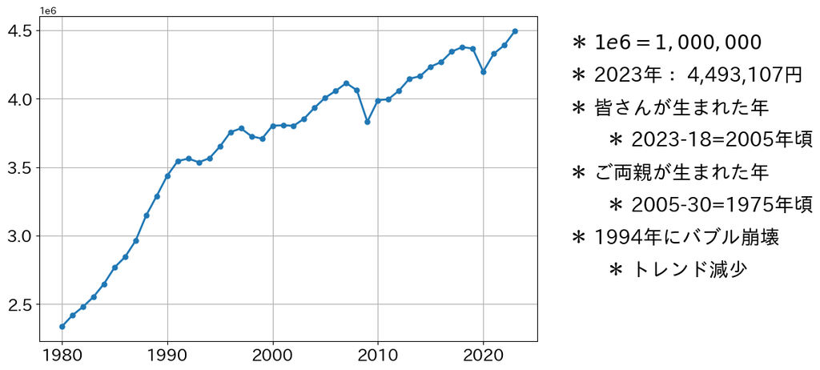

### 縦軸に`0`が多すぎるから対数を使おう！

- 縦軸：`1e6`$=10^6=1,000,000$
- 対数について $$ \begin{align*} &x=10^y\qquad\Leftrightarrow\qquad y=\log_{10}x\\ &\\ &\Updownarrow\\ &\\ x\text{は}10\text{の}&y\text{乗と等しい。} \end{align*} $$
- 例 $$1000=10^3\qquad\Leftrightarrow\qquad 3=\log_{10}1000$$

$$10,000=10^{4}\qquad\Leftrightarrow\qquad 4=\log_{10}10,000$$

$$5000\approx10^{3.7}\qquad\Leftrightarrow\qquad 3.7\approx\log_{10}5,000$$

- **常用対数** → 対数の底：`10`

### 対数の底に`10`を必ず使う必要はない！

- $e\approx 2.718\cdots$（ネイピア数、無理数）
- $e$を対数の底に使う　→　**自然対数**

$$ \begin{align*} &x=e^y\qquad\Leftrightarrow\qquad y=\log_{e}x\\ &\\ &\Updownarrow\\ &\\ x\text{は}e\text{の}&y\text{乗と等しい。} \end{align*} $$

- 例 $$1000\approx e^{6.908}\qquad\Leftrightarrow\qquad 6.908\approx\log_{e}1000$$

$$4,000,000\approx e^{15.2}\qquad\Leftrightarrow\qquad 15.2\approx\log_{e}4,000,000$$

- 自然対数を使って何がうれしいの？

### 一人当たりGDP（対数）の推移

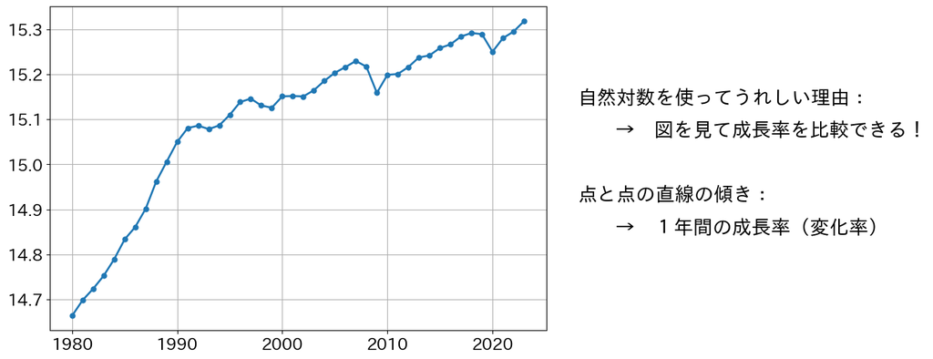

### 成長率（変化率）の計算方法

- $\text{GDP}_t$：$t$年のGDP
- GDPの成長率（変化率）

  $$g_t=\frac{\text{GDP}_{t}}{\text{GDP}_{t-1}}-1$$
- 例
  - $\text{GDP}_{t}=105$
  - $\text{GDP}_{t-1}=100$

  $$0.05=\frac{105}{100}-1\quad\Rightarrow\quad\text{5％}$$

### 一人当たりGDPの成長率

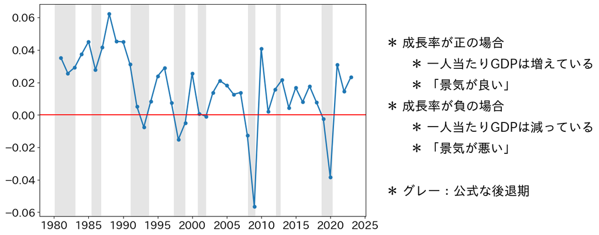

## 他国との比較

- Penn World Table 10.01
- `1954`〜`2019`年
  - 時系列データ
- `183`の国と地域
  - パネルデータ → 大勢の人物の動画のイメージ
- 単位：International US$
- 実質：`2017`年価格

### `118`カ国の一人当たりGDPの推移

- `1954`〜`2019`年

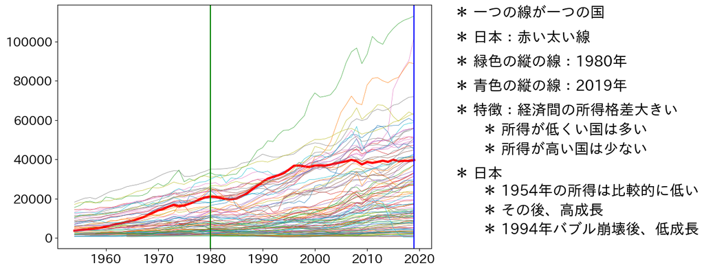

### `118`カ国の一人当たりGDP（自然対数）の推移

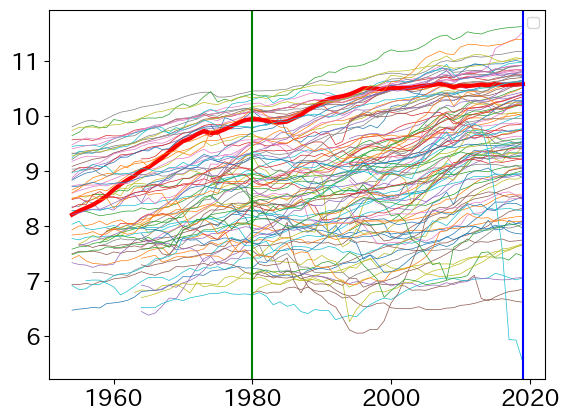

### 2019年の一人当たりGDP（114カ国）

- 横断面データ → 大勢の集合写真のイメージ

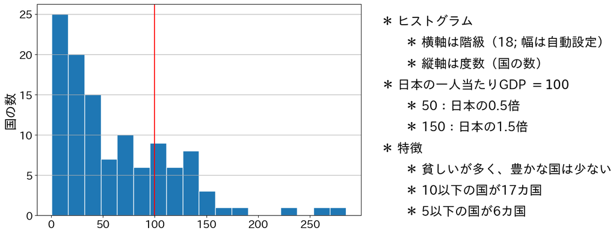

- 横断面データ → 大勢の集合写真のイメージ

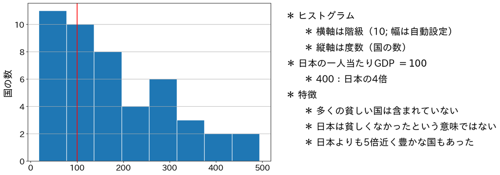

## 長期データで見る一人当たりGDP

- Maddison Historical Dataset
- `1850`〜`2022`年
- 単位：米ドル（2011年）
- 主要国と比較

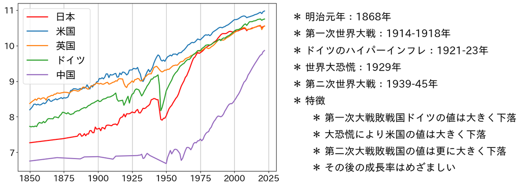

### 日本とドイツのキャッチ・アップ（Catch-up）

1. 技術伝播
   - 例：プラスチック（重工業）、トランジスタ
   - 更なるイノベーションにも繋がった
   - 技術進歩率（`1954`-`1975`年）
     - `46`カ国中`4`位
2. 資本ストックの蓄積
   - `1954 → 1975年
   - 約`7.2`倍（年`9.9`％増加率）
   - `46`カ国中`1`位
3. 教育水準の向上
   - 高校進学率
     - 約`52`％（`1954`年）→ 約`92`％（`1975`年）
   - 大学進学率
     - 約`10`％（`1954`年）→ 約`39`％（`1975`年）
   - 人的資本指数の伸び率
     - `46`カ国中`12`位

### 1975年頃から成長率は鈍化

- 技術伝播 $\approx$ 技術の模倣の限界
  - 欧米の当時の最新技術に近付くと技術の新しい技術が必要となるが、はるかに難しい
- 資本蓄積 → 資本の限界生産性の逓減（ていげん）
  - 戦争により資本の破壊　→　$\dfrac{K}{L}$小　→ （イメージ）労働者は大勢、しかし、資本が少ない
  - **【思考実験】**
    - 人口、教育水準、技術水準を戦後直後の水準に固定し変化しないと考えてみよう。
    - 最初に導入される資本１単位（例、１台目の車）は生産の上昇に大きく貢献 → 成長率を引き上げる
    - 次の資本１単位（例、２台目の車）も同様 → 成長率を引き上げる
    - しかし、資本が蓄積されると、追加的に導入される資本のインパクトは減少していく → 成長率に対する効果が逓減
      - 資本の限界効果の逓減
  - 人口増加、教育水準と技術水準が向上があっても、資本の限界効果の逓減は残る

## 超長期の一人当たりGDP

### 日本と英国の一人当たりGDP

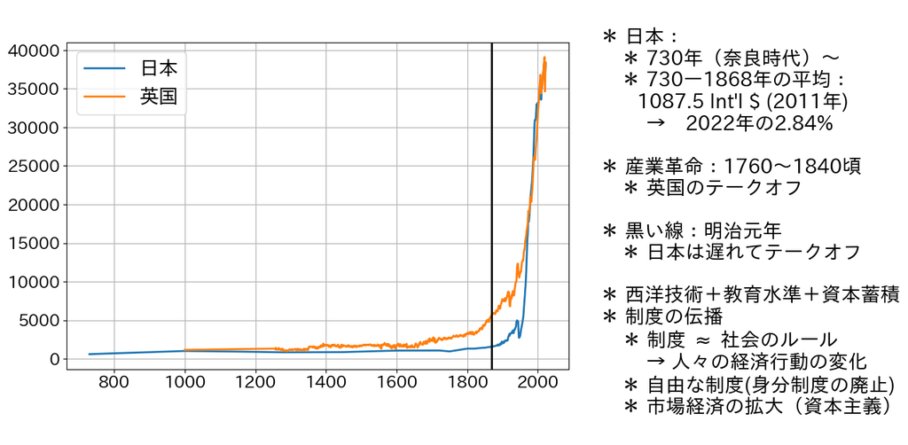

### テークオフの伝播

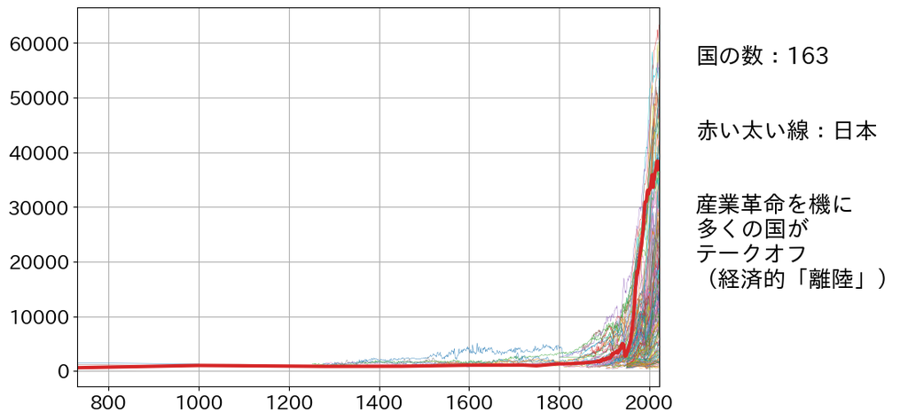

### 産業革命からの時期

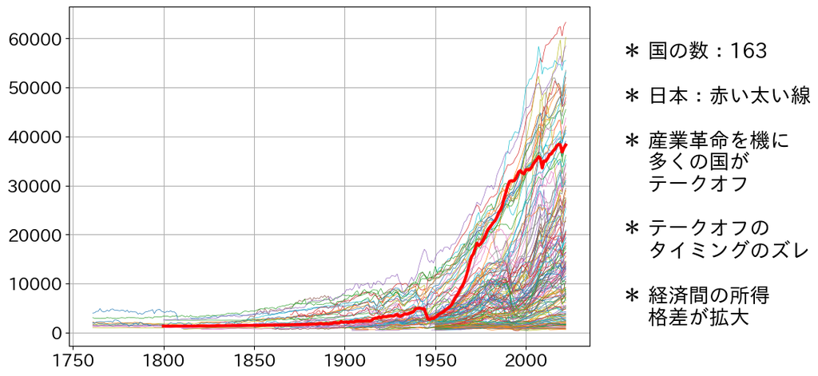

## まとめ

- GDP = 総生産 = 総支出 = 総所得
- 一人当たりGDP = 「平均的な人」で捉えた生活水準
- 多くの国が産業革命後に爆発的な経済発展
  - 日本も明治維新を機に
    - 技術伝播
    - 資本蓄積
    - 教育水準の向上
    - 制度の伝播
- 戦後の急成長
- バブル景気の崩壊後の低成長
  - なぜ？ → 様々な研究